# data_science_-_python

## Project Title: “Melbourne house price data" Name: “Vikash Pateshwari" Email: “vikash.pateshwari@wipro.com" Company : “Wipro Technology” output: html_document , .ipynb , .py

## Business Understanding

### Melbourne house price data

## Data Understanding

#### You can download the data from https://www.kaggle.com/anthonypino/melbourne-housing-market#Melbourne_housing_FULL.csv You can understand the data by looking at the data dictionary provided @ https://rpubs.com/kunaljubce/mlb_housing_data

#### Import the data set in Python. View the dataset See the structure and the summary of the dataset to understand the data. Find out the number of: Numeric attributes: Categorical attributes:

```python
#1.Import the data set in Python.
#downloaded the data sets
import numpy as np
import pandas as pd
full = pd.read_csv(r'C:\Users\imvik\Wipro Assignment\AI\data_science_-_python\melbourne-housing-market\Melbourne_housing_FULL.csv')
```

```python
#2.View the dataset
#head for top 5 rows or tail for 5 last items
#full.tail()
full.head()
```

|  | Suburb | Address | Rooms | Type | Price | Method | SellerG | Date | Distance | Postcode | ... | Bathroom | Car | Landsize | BuildingArea | YearBuilt | CouncilArea | Lattitude | Longtitude | Regionname | Propertycount |
| --- | --- | --- | --- | --- | --- | --- | --- | --- | --- | --- | --- | --- | --- | --- | --- | --- | --- | --- | --- | --- | --- |
| 0 | Abbotsford | 68 Studley St | 2 | h | NaN | SS | Jellis | 3/09/2016 | 2.5 | 3067.0 | ... | 1.0 | 1.0 | 126.0 | NaN | NaN | Yarra City Council | -37.8014 | 144.9958 | Northern Metropolitan | 4019.0 |
| 1 | Abbotsford | 85 Turner St | 2 | h | 1480000.0 | S | Biggin | 3/12/2016 | 2.5 | 3067.0 | ... | 1.0 | 1.0 | 202.0 | NaN | NaN | Yarra City Council | -37.7996 | 144.9984 | Northern Metropolitan | 4019.0 |
| 2 | Abbotsford | 25 Bloomburg St | 2 | h | 1035000.0 | S | Biggin | 4/02/2016 | 2.5 | 3067.0 | ... | 1.0 | 0.0 | 156.0 | 79.0 | 1900.0 | Yarra City Council | -37.8079 | 144.9934 | Northern Metropolitan | 4019.0 |
| 3 | Abbotsford | 18/659 Victoria St | 3 | u | NaN | VB | Rounds | 4/02/2016 | 2.5 | 3067.0 | ... | 2.0 | 1.0 | 0.0 | NaN | NaN | Yarra City Council | -37.8114 | 145.0116 | Northern Metropolitan | 4019.0 |
| 4 | Abbotsford | 5 Charles St | 3 | h | 1465000.0 | SP | Biggin | 4/03/2017 | 2.5 | 3067.0 | ... | 2.0 | 0.0 | 134.0 | 150.0 | 1900.0 | Yarra City Council | -37.8093 | 144.9944 | Northern Metropolitan | 4019.0 |

5 rows × 21 columns

```python
#See the structure and the summary of the dataset to understand the data.
full.info()
```

```
<class 'pandas.core.frame.DataFrame'>
RangeIndex: 34857 entries, 0 to 34856
Data columns (total 21 columns):
Suburb           34857 non-null object
Address          34857 non-null object
Rooms            34857 non-null int64
Type             34857 non-null object
Price            27247 non-null float64
Method           34857 non-null object
SellerG          34857 non-null object
Date             34857 non-null object
Distance         34856 non-null float64
Postcode         34856 non-null float64
Bedroom2         26640 non-null float64
Bathroom         26631 non-null float64
Car              26129 non-null float64
Landsize         23047 non-null float64
BuildingArea     13742 non-null float64
YearBuilt        15551 non-null float64
CouncilArea      34854 non-null object
Lattitude        26881 non-null float64
Longtitude       26881 non-null float64
Regionname       34854 non-null object
Propertycount    34854 non-null float64
dtypes: float64(12), int64(1), object(8)
memory usage: 5.6+ MB
```

```python
full.shape
```

```
(34857, 21)
```

```python
full.columns
```

```
Index(['Suburb', 'Address', 'Rooms', 'Type', 'Price', 'Method', 'SellerG',
       'Date', 'Distance', 'Postcode', 'Bedroom2', 'Bathroom', 'Car',
       'Landsize', 'BuildingArea', 'YearBuilt', 'CouncilArea', 'Lattitude',
       'Longtitude', 'Regionname', 'Propertycount'],
      dtype='object')
```

```python
full.describe()
```

|  | Rooms | Price | Distance | Postcode | Bedroom2 | Bathroom | Car | Landsize | BuildingArea | YearBuilt | Lattitude | Longtitude | Propertycount |
| --- | --- | --- | --- | --- | --- | --- | --- | --- | --- | --- | --- | --- | --- |
| count | 34857.000000 | 2.724700e+04 | 34856.000000 | 34856.000000 | 26640.000000 | 26631.000000 | 26129.000000 | 23047.000000 | 13742.00000 | 15551.000000 | 26881.000000 | 26881.000000 | 34854.000000 |
| mean | 3.031012 | 1.050173e+06 | 11.184929 | 3116.062859 | 3.084647 | 1.624798 | 1.728845 | 593.598993 | 160.25640 | 1965.289885 | -37.810634 | 145.001851 | 7572.888306 |
| std | 0.969933 | 6.414671e+05 | 6.788892 | 109.023903 | 0.980690 | 0.724212 | 1.010771 | 3398.841946 | 401.26706 | 37.328178 | 0.090279 | 0.120169 | 4428.090313 |
| min | 1.000000 | 8.500000e+04 | 0.000000 | 3000.000000 | 0.000000 | 0.000000 | 0.000000 | 0.000000 | 0.00000 | 1196.000000 | -38.190430 | 144.423790 | 83.000000 |
| 25% | 2.000000 | 6.350000e+05 | 6.400000 | 3051.000000 | 2.000000 | 1.000000 | 1.000000 | 224.000000 | 102.00000 | 1940.000000 | -37.862950 | 144.933500 | 4385.000000 |
| 50% | 3.000000 | 8.700000e+05 | 10.300000 | 3103.000000 | 3.000000 | 2.000000 | 2.000000 | 521.000000 | 136.00000 | 1970.000000 | -37.807600 | 145.007800 | 6763.000000 |
| 75% | 4.000000 | 1.295000e+06 | 14.000000 | 3156.000000 | 4.000000 | 2.000000 | 2.000000 | 670.000000 | 188.00000 | 2000.000000 | -37.754100 | 145.071900 | 10412.000000 |
| max | 16.000000 | 1.120000e+07 | 48.100000 | 3978.000000 | 30.000000 | 12.000000 | 26.000000 | 433014.000000 | 44515.00000 | 2106.000000 | -37.390200 | 145.526350 | 21650.000000 |

```python
#Find out the number of:
#    Numeric attributes:
numeric = full.select_dtypes(exclude='object')
len(numeric.columns)
```

```
13
```

```python
#    Categorical attributes:
categorical= full.select_dtypes(include='object')
len(categorical.columns)
```

```
8
```

## Data Preparation : Data Cleaning

- Duplicate values: Identify if the datasets have duplicate values or not and remove the duplicate values.
- Find out the number of rows present in the dataset
- Before removing duplicate values
- After removing duplicate values
- Variable type: Check if all the variables have the correct variable type, based on the data dictionary. If not, then change them.
- For how many attributes did you need to change the data type?
- Missing value treatment: Check which variables have missing values and use appropriate treatments.
- For each of the variables, find the number of missing values and provide the value that they have been imputed with.
- Outlier Treatment:
- Identify the varibales : Make a subset of the dataset with all the numeric variables.
- Outliers : For each variable of this subset, carry out the outlier detection. Find out the percentile distribution of each variable and carry out capping and flooring for outlier values.

```python
#Duplicate values: Identify if the datasets have duplicate values or not and remove the duplicate values.
full[full.duplicated()]
```

|  | Suburb | Address | Rooms | Type | Price | Method | SellerG | Date | Distance | Postcode | ... | Bathroom | Car | Landsize | BuildingArea | YearBuilt | CouncilArea | Lattitude | Longtitude | Regionname | Propertycount |
| --- | --- | --- | --- | --- | --- | --- | --- | --- | --- | --- | --- | --- | --- | --- | --- | --- | --- | --- | --- | --- | --- |
| 15858 | Nunawading | 1/7 Lilian St | 3 | t | NaN | SP | Jellis | 17/06/2017 | 15.4 | 3131.0 | ... | 3.0 | 2.0 | 405.0 | 226.0 | 2000.0 | Manningham City Council | -37.82678 | 145.16777 | Eastern Metropolitan | 4973.0 |

1 rows × 21 columns

```python
#Find out the number of rows present in the dataset
#Before removing duplicate values
duplicate = full.duplicated()
duplicate.count()
```

```
34857
```

```python
#After removing duplicate values
remdupl = full.drop_duplicates()
len(remdupl)
```

```
34856
```

```python
#Variable type: Check if all the variables have the correct variable type,
#               based on the data dictionary. If not, then change them.
full.dtypes
```

```
Suburb            object
Address           object
Rooms              int64
Type              object
Price            float64
Method            object
SellerG           object
Date              object
Distance         float64
Postcode         float64
Bedroom2         float64
Bathroom         float64
Car              float64
Landsize         float64
BuildingArea     float64
YearBuilt        float64
CouncilArea       object
Lattitude        float64
Longtitude       float64
Regionname        object
Propertycount    float64
dtype: object
```

```python
#as object is not  datatype so it need to converted in cateogical data type.
objectdtye = full.select_dtypes({object}).columns
objectdtye
```

```
Index(['Suburb', 'Address', 'Type', 'Method', 'SellerG', 'Date', 'CouncilArea',
       'Regionname'],
      dtype='object')
```

```python
full[objectdtye] = full[objectdtye].astype('category')
```

```python
#For how many attributes did you need to change the data type?
full.info()
#from below info we can check there are 8 categorical data.
#dtypes: category(8), float64(12), int64(1)
```

```
<class 'pandas.core.frame.DataFrame'>
RangeIndex: 34857 entries, 0 to 34856
Data columns (total 21 columns):
Suburb           34857 non-null category
Address          34857 non-null category
Rooms            34857 non-null int64
Type             34857 non-null category
Price            27247 non-null float64
Method           34857 non-null category
SellerG          34857 non-null category
Date             34857 non-null category
Distance         34856 non-null float64
Postcode         34856 non-null float64
Bedroom2         26640 non-null float64
Bathroom         26631 non-null float64
Car              26129 non-null float64
Landsize         23047 non-null float64
BuildingArea     13742 non-null float64
YearBuilt        15551 non-null float64
CouncilArea      34854 non-null category
Lattitude        26881 non-null float64
Longtitude       26881 non-null float64
Regionname       34854 non-null category
Propertycount    34854 non-null float64
dtypes: category(8), float64(12), int64(1)
memory usage: 5.4 MB
```

```python
#Missing value treatment: Check which variables have missing values and use appropriate treatments.
#For each of the variables, find the number of missing values and provide the value that they have been imputed with.
full.isnull().sum()
```

```
Suburb               0
Address              0
Rooms                0
Type                 0
Price             7610
Method               0
SellerG              0
Date                 0
Distance             1
Postcode             1
Bedroom2          8217
Bathroom          8226
Car               8728
Landsize         11810
BuildingArea     21115
YearBuilt        19306
CouncilArea          3
Lattitude         7976
Longtitude        7976
Regionname           3
Propertycount        3
dtype: int64
```

```python
#droping missing value columns
full1 = full
len(full1), len(full1.dropna())
```

```
(34857, 8887)
```

```python
#method 2 imputing the values
full1.isna().sum()
```

```
Suburb               0
Address              0
Rooms                0
Type                 0
Price             7610
Method               0
SellerG              0
Date                 0
Distance             1
Postcode             1
Bedroom2          8217
Bathroom          8226
Car               8728
Landsize         11810
BuildingArea     21115
YearBuilt        19306
CouncilArea          3
Lattitude         7976
Longtitude        7976
Regionname           3
Propertycount        3
dtype: int64
```

```python
Price_mean = full1.Price.mean()
Distance_mean = full1.Distance.mean()
Postcode_mean = full1.Postcode.mean()
Bedroom2_mean = full1.Bedroom2.mean()
Bathroom_mean = full1.Bathroom.mean()
Car_mean = full1.Car.mean()
Landsize_mean = full1.Landsize.mean()
BuildingArea_mean = full1.BuildingArea.mean()
YearBuilt_mean = full1.YearBuilt.mean()
Lattitude_mean = full1.Lattitude.mean()
Longtitude_mean = full1.Longtitude.mean()
Propertycount_mean = full1.Propertycount.mean()
full1.fillna(value = {'Price':Price_mean
                      ,'Distance':Distance_mean
                      ,'Postcode':int(Postcode_mean)
                      ,'Bedroom2':Bedroom2_mean
                      ,'Car':Car_mean
                      ,'Bathroom':Bathroom_mean
                      ,'Landsize':Landsize_mean
                      ,'BuildingArea':BuildingArea_mean
                      ,'YearBuilt':int(YearBuilt_mean)
                      ,'Lattitude':Lattitude_mean
                      ,'Longtitude':Longtitude_mean
                      ,'Propertycount':Propertycount_mean
                      ,'CouncilArea' : 'Boroondara City Council'#we are taking most used categroical value_counts()
                      ,'Regionname' :'Southern Metropolitan'} #we are taking most used categroical value_counts()
                      ,inplace = True
                      )
#full1["Price"].fillna( method ='ffill')
```

```python
full1.isna().sum()
```

```
Suburb           0
Address          0
Rooms            0
Type             0
Price            0
Method           0
SellerG          0
Date             0
Distance         0
Postcode         0
Bedroom2         0
Bathroom         0
Car              0
Landsize         0
BuildingArea     0
YearBuilt        0
CouncilArea      0
Lattitude        0
Longtitude       0
Regionname       0
Propertycount    0
dtype: int64
```

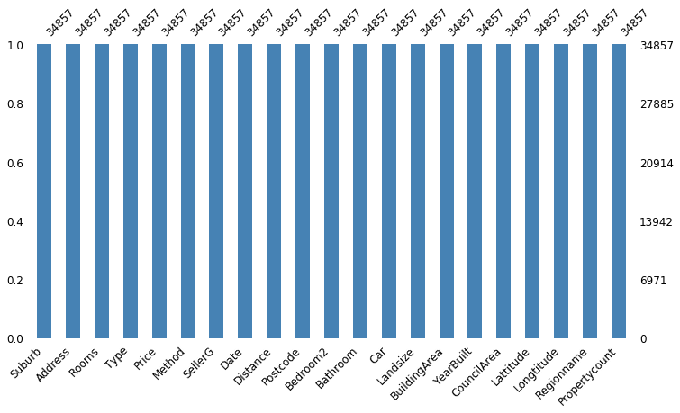

```python
#missing no library offers a very nice way to visualize the distribution of NaN values.
import missingno as msno
import matplotlib.pyplot as plt
%matplotlib inline
msno.bar(full1, figsize=(12, 6), fontsize=12, color='steelblue')
```

```python
#Outlier Treatment:
#Identify the varibales : Make a subset of the dataset with all the numeric variables.
full1_numeric=full1.select_dtypes(['int64','float64'])
full1_numeric.head()
```

|  | Rooms | Price | Distance | Postcode | Bedroom2 | Bathroom | Car | Landsize | BuildingArea | YearBuilt | Lattitude | Longtitude | Propertycount |
| --- | --- | --- | --- | --- | --- | --- | --- | --- | --- | --- | --- | --- | --- |
| 0 | 2 | 1.050173e+06 | 2.5 | 3067.0 | 2.0 | 1.0 | 1.0 | 126.0 | 160.2564 | 1965.0 | -37.8014 | 144.9958 | 4019.0 |
| 1 | 2 | 1.480000e+06 | 2.5 | 3067.0 | 2.0 | 1.0 | 1.0 | 202.0 | 160.2564 | 1965.0 | -37.7996 | 144.9984 | 4019.0 |
| 2 | 2 | 1.035000e+06 | 2.5 | 3067.0 | 2.0 | 1.0 | 0.0 | 156.0 | 79.0000 | 1900.0 | -37.8079 | 144.9934 | 4019.0 |
| 3 | 3 | 1.050173e+06 | 2.5 | 3067.0 | 3.0 | 2.0 | 1.0 | 0.0 | 160.2564 | 1965.0 | -37.8114 | 145.0116 | 4019.0 |
| 4 | 3 | 1.465000e+06 | 2.5 | 3067.0 | 3.0 | 2.0 | 0.0 | 134.0 | 150.0000 | 1900.0 | -37.8093 | 144.9944 | 4019.0 |

```python
#Outliers : For each variable of this subset, carry out the outlier detection.
#          Find out the percentile distribution of each #variable and carry out capping and flooring for outlier values
full1_numeric.describe()
#75% is Q3
#25% is Q1
#IQR=Q3-Q1
#floor = Q1 -1.5*IQR
#cap=Q3+1.5*IQR
#we can also use full1_numeric['Rooms'].quantile(0.25) to get Q1 Value.
```

|  | Rooms | Price | Distance | Postcode | Bedroom2 | Bathroom | Car | Landsize | BuildingArea | YearBuilt | Lattitude | Longtitude | Propertycount |
| --- | --- | --- | --- | --- | --- | --- | --- | --- | --- | --- | --- | --- | --- |
| count | 34857.000000 | 3.485700e+04 | 34857.000000 | 34857.000000 | 34857.000000 | 34857.000000 | 34857.000000 | 34857.000000 | 34857.000000 | 34857.000000 | 34857.000000 | 34857.000000 | 34857.000000 |
| mean | 3.031012 | 1.050173e+06 | 11.184929 | 3116.062857 | 3.084647 | 1.624798 | 1.728845 | 593.598993 | 160.256400 | 1965.129328 | -37.810634 | 145.001851 | 7572.888306 |
| std | 0.969933 | 5.671357e+05 | 6.788795 | 109.022339 | 0.857337 | 0.633013 | 0.875119 | 2763.694121 | 251.943934 | 24.932766 | 0.079280 | 0.105528 | 4427.899750 |
| min | 1.000000 | 8.500000e+04 | 0.000000 | 3000.000000 | 0.000000 | 0.000000 | 0.000000 | 0.000000 | 0.000000 | 1196.000000 | -38.190430 | 144.423790 | 83.000000 |
| 25% | 2.000000 | 6.950000e+05 | 6.400000 | 3051.000000 | 3.000000 | 1.000000 | 1.000000 | 357.000000 | 160.000000 | 1965.000000 | -37.846900 | 144.964400 | 4385.000000 |
| 50% | 3.000000 | 1.050173e+06 | 10.300000 | 3103.000000 | 3.000000 | 1.624798 | 1.728845 | 593.598993 | 160.256400 | 1965.000000 | -37.810634 | 145.001851 | 6763.000000 |
| 75% | 4.000000 | 1.150000e+06 | 14.000000 | 3156.000000 | 3.084647 | 2.000000 | 2.000000 | 598.000000 | 160.256400 | 1965.000000 | -37.770900 | 145.051750 | 10412.000000 |
| max | 16.000000 | 1.120000e+07 | 48.100000 | 3978.000000 | 30.000000 | 12.000000 | 26.000000 | 433014.000000 | 44515.000000 | 2106.000000 | -37.390200 | 145.526350 | 21650.000000 |

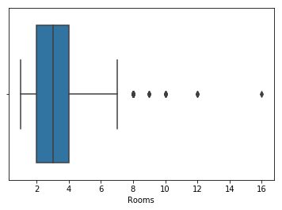

```python
#BoxPlot for variable "Rooms"
import seaborn as sns
sns.boxplot(x=full1_numeric['Rooms'])
```

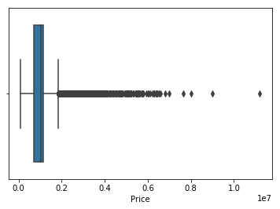

```python
sns.boxplot(x=full1_numeric['Price'])
```

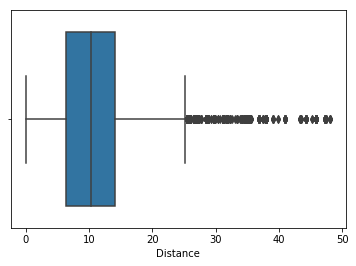

```python
sns.boxplot(x=full1_numeric['Distance'])
```

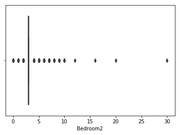

```python
sns.boxplot(x=full1_numeric['Bedroom2'])
```

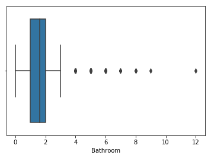

```python
sns.boxplot(x=full1_numeric['Bathroom'])
```

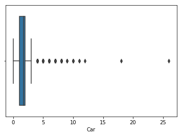

```python
sns.boxplot(x=full1_numeric['Car'])
```

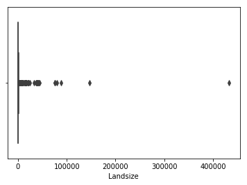

```python
sns.boxplot(x=full1_numeric['Landsize'])
```

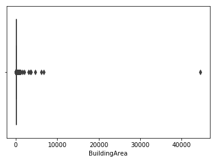

```python
sns.boxplot(x=full1_numeric['BuildingArea'])
```

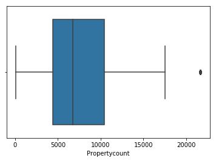

```python
sns.boxplot(x=full1_numeric['Propertycount'])
```

```python
for col in full1_numeric:
    if col!='Lattitude' and col!='Longtitude':# not considering Lattitude & Longitude as Outlier treatment
        print("\n\nOutlier for ",col)
        # Cap=IQ3+1.5*IQR & Floor=1.5*IQR-IQ1
        Q1 = full1_numeric[col].quantile(0.25)
        Q3 = full1_numeric[col].quantile(0.75)
        IQR = Q3 - Q1
        print("IQR for ",col,"=",IQR)
        limit=1.5*IQR
        floor = limit - Q1
        print("Floor for ",col,"=",floor)
        Cap = Q3 + limit
        print("Cap for ",col,"=",Cap)
        #values less than (1.5*IQR-Q1) and more than (1.5*IQR+Q3) are removed.
        #Removing Outlier values for Price due to Large number
        if col=='Price':
            full1_numeric=full1_numeric[(full1_numeric[col]>=floor)&(full1_numeric[col]<=Cap)]
            print(full1_numeric.shape)
```

```
Outlier for  Rooms
IQR for  Rooms = 2.0
Floor for  Rooms = 1.0
Cap for  Rooms = 7.0


Outlier for  Price
IQR for  Price = 455000.0
Floor for  Price = -12500.0
Cap for  Price = 1832500.0
(32301, 13)


Outlier for  Distance
IQR for  Distance = 7.799999999999999
Floor for  Distance = 5.299999999999999
Cap for  Distance = 25.9


Outlier for  Postcode
IQR for  Postcode = 107.0
Floor for  Postcode = -2885.5
Cap for  Postcode = 3313.5


Outlier for  Bedroom2
IQR for  Bedroom2 = 0.08464714714714727
Floor for  Bedroom2 = -2.873029279279279
Cap for  Bedroom2 = 3.211617867867868


Outlier for  Bathroom
IQR for  Bathroom = 1.0
Floor for  Bathroom = 0.5
Cap for  Bathroom = 3.5


Outlier for  Car
IQR for  Car = 1.0
Floor for  Car = 0.5
```

[output cut: 10 more lines]

```
IQR for  BuildingArea = 7.256400356571106
Floor for  BuildingArea = -142.11539946514335
Cap for  BuildingArea = 171.14100089142778


Outlier for  YearBuilt
IQR for  YearBuilt = 1.0
Floor for  YearBuilt = -1963.5
Cap for  YearBuilt = 1967.5


Outlier for  Propertycount
IQR for  Propertycount = 6118.0
Floor for  Propertycount = 4883.0
Cap for  Propertycount = 19589.0
```

## Data Preparation Feature Engineering:

### Feature Transformation:

#### Identify variables that have non-linear trends. How many variables have non-linear trends? Transform them (as required)

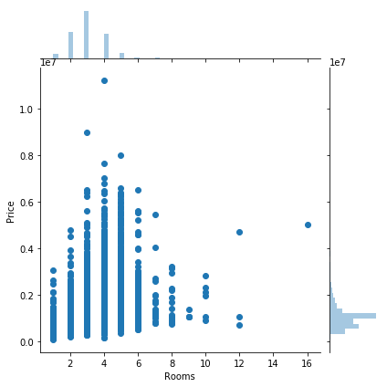

```python
#Identify variables that have non-linear trends
sns.jointplot(x='Rooms',y='Price',data=full1,kind='scatter')
```

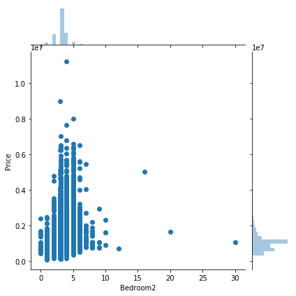

```python
sns.jointplot(x='Bedroom2',y='Price',data=full1,kind='scatter')
```

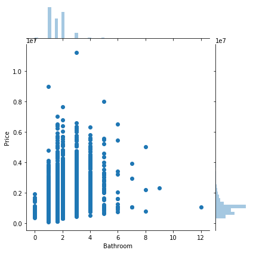

```python
sns.jointplot(x='Bathroom',y='Price',data=full1,kind='scatter')
```

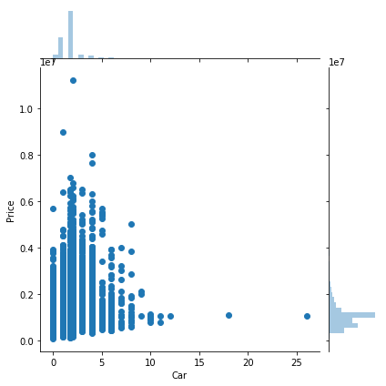

```python
sns.jointplot(x='Car',y='Price',data=full1,kind='scatter')
```

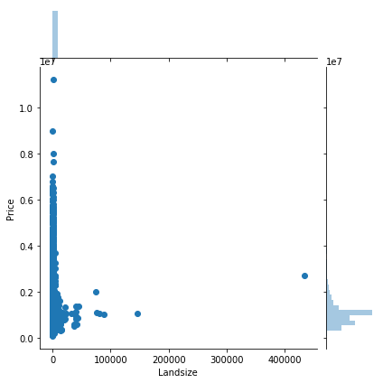

```python
sns.jointplot(x='Landsize',y='Price',data=full1,kind='scatter')
```

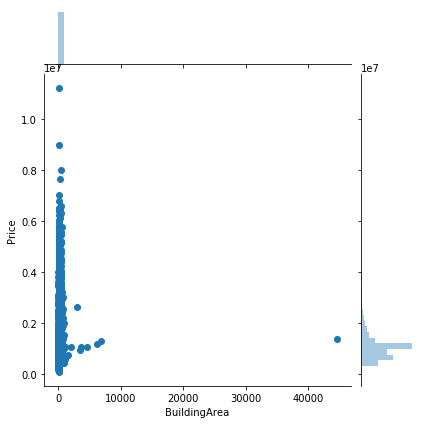

```python
sns.jointplot(x='BuildingArea',y='Price',data=full1,kind='scatter')
```

```python
# Matrix form for correlation data
full1.corr()
```

|  | Rooms | Price | Distance | Postcode | Bedroom2 | Bathroom | Car | Landsize | BuildingArea | YearBuilt | Lattitude | Longtitude | Propertycount |
| --- | --- | --- | --- | --- | --- | --- | --- | --- | --- | --- | --- | --- | --- |
| Rooms | 1.000000 | 0.404908 | 0.271511 | 0.085890 | 0.819099 | 0.529191 | 0.337780 | 0.030136 | 0.098468 | -0.008246 | 0.004254 | 0.090140 | -0.071675 |
| Price | 0.404908 | 1.000000 | -0.186848 | 0.040511 | 0.327485 | 0.324631 | 0.154545 | 0.026460 | 0.065301 | -0.200594 | -0.170840 | 0.154873 | -0.052934 |
| Distance | 0.271511 | -0.186848 | 1.000000 | 0.481566 | 0.239091 | 0.111939 | 0.211768 | 0.048717 | 0.050110 | 0.220729 | -0.089506 | 0.179113 | -0.018140 |
| Postcode | 0.085890 | 0.040511 | 0.481566 | 1.000000 | 0.080398 | 0.108110 | 0.060746 | 0.032452 | 0.029252 | 0.063470 | -0.208542 | 0.327576 | 0.017108 |
| Bedroom2 | 0.819099 | 0.327485 | 0.239091 | 0.080398 | 1.000000 | 0.614737 | 0.385459 | 0.034578 | 0.110089 | -0.001555 | 0.003431 | 0.105682 | -0.045785 |
| Bathroom | 0.529191 | 0.324631 | 0.111939 | 0.108110 | 0.614737 | 1.000000 | 0.305530 | 0.034007 | 0.107991 | 0.130616 | -0.058905 | 0.106059 | -0.028168 |
| Car | 0.337780 | 0.154545 | 0.211768 | 0.060746 | 0.385459 | 0.305530 | 1.000000 | 0.034846 | 0.074810 | 0.095065 | -0.008943 | 0.046613 | -0.008171 |
| Landsize | 0.030136 | 0.026460 | 0.048717 | 0.032452 | 0.034578 | 0.034007 | 0.034846 | 1.000000 | 0.085636 | 0.010427 | 0.022734 | -0.002323 | -0.014453 |
| BuildingArea | 0.098468 | 0.065301 | 0.050110 | 0.029252 | 0.110089 | 0.107991 | 0.074810 | 0.085636 | 1.000000 | 0.013803 | 0.012526 | -0.001562 | -0.015003 |
| YearBuilt | -0.008246 | -0.200594 | 0.220729 | 0.063470 | -0.001555 | 0.130616 | 0.095065 | 0.010427 | 0.013803 | 1.000000 | 0.069606 | -0.016935 | 0.014488 |
| Lattitude | 0.004254 | -0.170840 | -0.089506 | -0.208542 | 0.003431 | -0.058905 | -0.008943 | 0.022734 | 0.012526 | 0.069606 | 1.000000 | -0.345589 | 0.009574 |
| Longtitude | 0.090140 | 0.154873 | 0.179113 | 0.327576 | 0.105682 | 0.106059 | 0.046613 | -0.002323 | -0.001562 | -0.016935 | -0.345589 | 1.000000 | 0.014067 |
| Propertycount | -0.071675 | -0.052934 | -0.018140 | 0.017108 | -0.045785 | -0.028168 | -0.008171 | -0.014453 | -0.015003 | 0.014488 | 0.009574 | 0.014067 | 1.000000 |

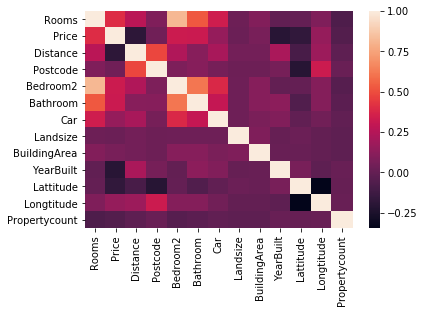

```python
sns.heatmap(full1.corr())
#Rooms, Bedroom2, Bathroom & Car have weak positive correlation with Price.
#Distance have weak weak negative correlation with Price
#Landsize & Building Area do not have much correlation with Price and it is having non-linear trend.
```